# Dataframes y series de tiempo

Autor/a

Carlos Lesmes

Fecha de publicación

1 de febrero de 2026

## 1 Introducción

Un data frame (`tibble` si se tiene instalado el paquete `dplyr`) es la estructura de datos más usada en R, se utiliza para almacenar datos en forma tabular, similar a una hoja de cálculo. Los dataframes son cruciales para el análisis de datos porque pueden almacenar diferentes tipos de datos (numeric, character, logical, etc.) en diferentes columnas, dentro de cada columna los datos deben ser del mismo tipo y deben tener la misma longitud. Los dataframes también reciben datos faltantes: `NA`. En las columnas van las variables y en las filas van las observaciones que se han tomado a un sujeto. Un dataframe es una lista.

## 2 Creación de un dataframe

**Código**

```r
df <- data.frame(
  "entero" = 1:4,
  "factor" = c("a", "b", "c", "d"),
  "número" = c(1.2, 3.4, 4.5, 5.6),
  "cadena" = as.character(c("a", "b", "c", "d"))
)
df
```

| entero | factor | número | cadena |
| --- | --- | --- | --- |
| 1 | a | 1.2 | a |
| 2 | b | 3.4 | b |
| 3 | c | 4.5 | c |
| 4 | d | 5.6 | d |

## 3 Características y atributos de un dataframe

**Código**

```r
dim(df)
```

```
[1] 4 4
```

**Código**

```r
length(df)
```

```
[1] 4
```

**Código**

```r
names(df)
```

```
[1] "entero" "factor" "número" "cadena"
```

**Código**

```r
str(df)
```

```
'data.frame':   4 obs. of  4 variables:
 $ entero: int  1 2 3 4
 $ factor: chr  "a" "b" "c" "d"
 $ número: num  1.2 3.4 4.5 5.6
 $ cadena: chr  "a" "b" "c" "d"
```

**Código**

```r
typeof(df)
```

```
[1] "list"
```

**Código**

```r
class(df)
```

```
[1] "data.frame"
```

**Código**

```r
summary(df)
```

```
     entero        factor              número         cadena
 Min.   :1.00   Length:4           Min.   :1.200   Length:4
 1st Qu.:1.75   Class :character   1st Qu.:2.850   Class :character
 Median :2.50   Mode  :character   Median :3.950   Mode  :character
 Mean   :2.50                      Mean   :3.675
 3rd Qu.:3.25                      3rd Qu.:4.775
 Max.   :4.00                      Max.   :5.600
```

## 4 Acceso a un dataframe

Acceso a las columnas

**Código**

```r
df$entero
```

```
[1] 1 2 3 4
```

**Código**

```r
df["entero"]
```

| entero |
| --- |
| 1 |
| 2 |
| 3 |
| 4 |

**Código**

```r
df[["entero"]]
```

```
[1] 1 2 3 4
```

## 5 Un dataframe más grande

Vuelos que salen de NYC en2023:

**Código**

```r
library(nycflights23)
df1 = flights
```

**Código**

```r
head(df1)
```

| year | month | day | dep_time | sched_dep_time | dep_delay | arr_time | sched_arr_time | arr_delay | carrier | flight | tailnum | origin | dest | air_time | distance | hour | minute | time_hour |
| --- | --- | --- | --- | --- | --- | --- | --- | --- | --- | --- | --- | --- | --- | --- | --- | --- | --- | --- |
| 2023 | 1 | 1 | 1 | 2038 | 203 | 328 | 3 | 205 | UA | 628 | N25201 | EWR | SMF | 367 | 2500 | 20 | 38 | 2023-01-01 20:00:00 |
| 2023 | 1 | 1 | 18 | 2300 | 78 | 228 | 135 | 53 | DL | 393 | N830DN | JFK | ATL | 108 | 760 | 23 | 0 | 2023-01-01 23:00:00 |
| 2023 | 1 | 1 | 31 | 2344 | 47 | 500 | 426 | 34 | B6 | 371 | N807JB | JFK | BQN | 190 | 1576 | 23 | 44 | 2023-01-01 23:00:00 |
| 2023 | 1 | 1 | 33 | 2140 | 173 | 238 | 2352 | 166 | B6 | 1053 | N265JB | JFK | CHS | 108 | 636 | 21 | 40 | 2023-01-01 21:00:00 |
| 2023 | 1 | 1 | 36 | 2048 | 228 | 223 | 2252 | 211 | UA | 219 | N17730 | EWR | DTW | 80 | 488 | 20 | 48 | 2023-01-01 20:00:00 |
| 2023 | 1 | 1 | 503 | 500 | 3 | 808 | 815 | -7 | AA | 499 | N925AN | EWR | MIA | 154 | 1085 | 5 | 0 | 2023-01-01 05:00:00 |

**Código**

```r
head(df1)
```

| year | month | day | dep_time | sched_dep_time | dep_delay | arr_time | sched_arr_time | arr_delay | carrier | flight | tailnum | origin | dest | air_time | distance | hour | minute | time_hour |
| --- | --- | --- | --- | --- | --- | --- | --- | --- | --- | --- | --- | --- | --- | --- | --- | --- | --- | --- |
| 2023 | 1 | 1 | 1 | 2038 | 203 | 328 | 3 | 205 | UA | 628 | N25201 | EWR | SMF | 367 | 2500 | 20 | 38 | 2023-01-01 20:00:00 |
| 2023 | 1 | 1 | 18 | 2300 | 78 | 228 | 135 | 53 | DL | 393 | N830DN | JFK | ATL | 108 | 760 | 23 | 0 | 2023-01-01 23:00:00 |
| 2023 | 1 | 1 | 31 | 2344 | 47 | 500 | 426 | 34 | B6 | 371 | N807JB | JFK | BQN | 190 | 1576 | 23 | 44 | 2023-01-01 23:00:00 |
| 2023 | 1 | 1 | 33 | 2140 | 173 | 238 | 2352 | 166 | B6 | 1053 | N265JB | JFK | CHS | 108 | 636 | 21 | 40 | 2023-01-01 21:00:00 |
| 2023 | 1 | 1 | 36 | 2048 | 228 | 223 | 2252 | 211 | UA | 219 | N17730 | EWR | DTW | 80 | 488 | 20 | 48 | 2023-01-01 20:00:00 |
| 2023 | 1 | 1 | 503 | 500 | 3 | 808 | 815 | -7 | AA | 499 | N925AN | EWR | MIA | 154 | 1085 | 5 | 0 | 2023-01-01 05:00:00 |

Las variables y la dimensión del dataframe.

**Código**

```r
names(df1)
```

```
 [1] "year"           "month"          "day"            "dep_time"
 [5] "sched_dep_time" "dep_delay"      "arr_time"       "sched_arr_time"
 [9] "arr_delay"      "carrier"        "flight"         "tailnum"
[13] "origin"         "dest"           "air_time"       "distance"
[17] "hour"           "minute"         "time_hour"
```

**Código**

```r
dim(df1)
```

```
[1] 435352     19
```

Para obtener descriptivos:

**Código**

```r
summary(df1)
```

```
      year          month             day           dep_time     sched_dep_time
 Min.   :2023   Min.   : 1.000   Min.   : 1.00   Min.   :   1    Min.   : 500
 1st Qu.:2023   1st Qu.: 3.000   1st Qu.: 8.00   1st Qu.: 931    1st Qu.: 930
 Median :2023   Median : 6.000   Median :16.00   Median :1357    Median :1359
 Mean   :2023   Mean   : 6.423   Mean   :15.74   Mean   :1366    Mean   :1364
 3rd Qu.:2023   3rd Qu.: 9.000   3rd Qu.:23.00   3rd Qu.:1804    3rd Qu.:1759
 Max.   :2023   Max.   :12.000   Max.   :31.00   Max.   :2400    Max.   :2359
                                                 NA's   :10738
   dep_delay          arr_time     sched_arr_time   arr_delay
 Min.   : -50.00   Min.   :   1    Min.   :   1   Min.   : -97.000
 1st Qu.:  -6.00   1st Qu.:1105    1st Qu.:1135   1st Qu.: -22.000
 Median :  -2.00   Median :1519    Median :1551   Median : -10.000
 Mean   :  13.84   Mean   :1497    Mean   :1552   Mean   :   4.345
 3rd Qu.:  10.00   3rd Qu.:1946    3rd Qu.:2007   3rd Qu.:   9.000
 Max.   :1813.00   Max.   :2400    Max.   :2359   Max.   :1812.000
 NA's   :10738     NA's   :11453                  NA's   :12534
   carrier              flight         tailnum             origin
 Length:435352      Min.   :   1.0   Length:435352      Length:435352
 Class :character   1st Qu.: 364.0   Class :character   Class :character
 Mode  :character   Median : 734.0   Mode  :character   Mode  :character
                    Mean   : 785.2
                    3rd Qu.:1188.0
                    Max.   :1972.0

     dest              air_time        distance           hour
 Length:435352      Min.   : 18.0   Min.   :  80.0   Min.   : 5.00
 Class :character   1st Qu.: 77.0   1st Qu.: 479.0   1st Qu.: 9.00
 Mode  :character   Median :121.0   Median : 762.0   Median :13.00
                    Mean   :141.8   Mean   : 977.5   Mean   :13.35
                    3rd Qu.:177.0   3rd Qu.:1182.0   3rd Qu.:17.00
                    Max.   :701.0   Max.   :4983.0   Max.   :23.00
                    NA's   :12534
     minute        time_hour
 Min.   : 0.00   Min.   :2023-01-01 05:00:00
 1st Qu.:10.00   1st Qu.:2023-03-30 20:00:00
 Median :29.00   Median :2023-06-27 08:00:00
 Mean   :28.53   Mean   :2023-06-29 10:02:22
 3rd Qu.:45.00   3rd Qu.:2023-09-27 11:00:00
 Max.   :59.00   Max.   :2023-12-31 23:00:00
```

## 7 Media de la distancia

**Código**

```r
mean(flights$distance)
```

```
[1] 977.503
```

## 8 Series de tiempo

Datos en *serie de tiempo* es una sucesión de datos tomados en espacios de tiempo igualmente espaciados.

### 8.1 Creación de series de tiempo

En el siguiente código `frequency` es el número de datos por año y `start` el período de inicio.

**Código**

```r
st = ts(1:100, frequency = 12, start = c(2025,3))
st
```

```
     Jan Feb Mar Apr May Jun Jul Aug Sep Oct Nov Dec
2025           1   2   3   4   5   6   7   8   9  10
2026  11  12  13  14  15  16  17  18  19  20  21  22
2027  23  24  25  26  27  28  29  30  31  32  33  34
2028  35  36  37  38  39  40  41  42  43  44  45  46
2029  47  48  49  50  51  52  53  54  55  56  57  58
2030  59  60  61  62  63  64  65  66  67  68  69  70
2031  71  72  73  74  75  76  77  78  79  80  81  82
2032  83  84  85  86  87  88  89  90  91  92  93  94
2033  95  96  97  98  99 100
```

**Código**

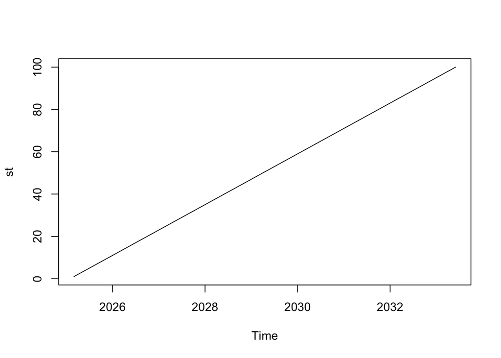

```r
plot.ts(st)
```

**Código**

```r
print(ts(1:10, frequency = 4, start = c(1959, 2)))
```

```
     Qtr1 Qtr2 Qtr3 Qtr4
1959         1    2    3
1960    4    5    6    7
1961    8    9   10
```

**Código**

```r
print( ts(1:10, frequency = 1, start = c(2025, 2)), calendar = TRUE)
```

```
2026 2027 2028 2029 2030 2031 2032 2033 2034 2035
   1    2    3    4    5    6    7    8    9   10
```

## 9 Series multivariadas

**Código**

```r
z <- ts(matrix(rnorm(300), 100, 3), start = c(1961, 1), frequency = 12)
class(z)
```

```
[1] "mts"    "ts"     "matrix" "array"
```

**Código**

```r
is.mts(z)
```

```
[1] TRUE
```

**Código**

```r
head(z)
```

```
          Series 1    Series 2   Series 3
Jan 1961 -1.243051 -0.09893316 -0.3984049
Feb 1961  3.107674 -0.84402921 -0.7738730
Mar 1961  1.180871 -1.39201161  0.4098630
Apr 1961  0.192505 -1.02856656  2.1142241
May 1961 -1.326834  0.53408196 -0.4704796
Jun 1961  1.078500  0.65125239 -2.6235045
```

**Código**

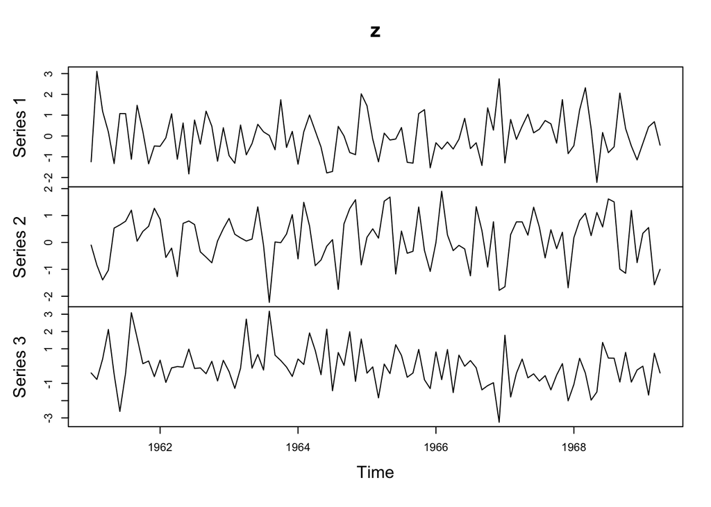

```r
plot(z)
```

**Código**

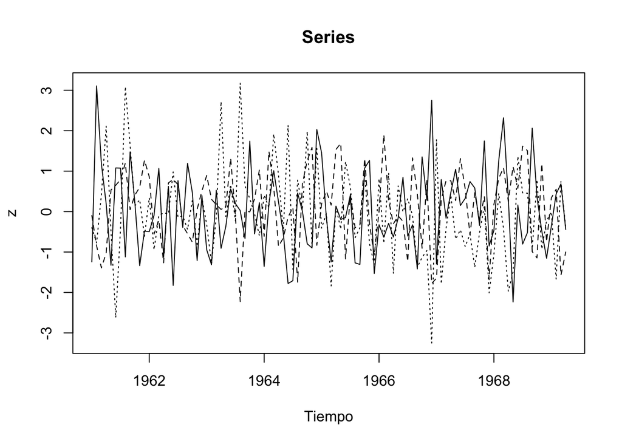

```r
plot(z, plot.type = "single", lty = 1:3, main="Series",xlab="Tiempo")
```

## 10 Paquete `dygraphs` para graficar series de tiempo

**Código**

```r
library(dygraphs)
dygraph(z)
```

[interactive chart not shown]

El paquete `xts` contiene una matriz con datos financieros llamada `sample_matrix`.

**Código**

```r
library(xts)
```

**Código**

```r
data(sample_matrix)
head(sample_matrix)
```

```
               Open     High      Low    Close
2007-01-02 50.03978 50.11778 49.95041 50.11778
2007-01-03 50.23050 50.42188 50.23050 50.39767
2007-01-04 50.42096 50.42096 50.26414 50.33236
2007-01-05 50.37347 50.37347 50.22103 50.33459
2007-01-06 50.24433 50.24433 50.11121 50.18112
2007-01-07 50.13211 50.21561 49.99185 49.99185
```

**Código**

```r
dygraph(sample_matrix) %>% dyRangeSelector()
```

[interactive chart not shown]

**Código**

```r
dygraph(sample_matrix) %>%
  dyCandlestick()
```

[interactive chart not shown]

Vea más en [dygraphs](https://rstudio.github.io/dygraphs/)

## 11 Estadísticas descriptivas

**Código**

```r
summary(sample_matrix)
```

```
      Open            High            Low            Close
 Min.   :47.19   Min.   :47.25   Min.   :47.09   Min.   :47.15
 1st Qu.:47.97   1st Qu.:48.03   1st Qu.:47.89   1st Qu.:47.92
 Median :49.60   Median :49.68   Median :49.46   Median :49.57
 Mean   :49.30   Mean   :49.40   Mean   :49.20   Mean   :49.29
 3rd Qu.:50.27   3rd Qu.:50.35   3rd Qu.:50.18   3rd Qu.:50.29
 Max.   :51.30   Max.   :51.32   Max.   :51.14   Max.   :51.18
```

**Código**

```r
colnames(sample_matrix)
```

```
[1] "Open"  "High"  "Low"   "Close"
```